# WI FastPlants: Ecosystem in plant indicators

Claudia Solis-Lemus

# Initial data: `ecosystem-data.csv`

### Reading the data

Reading in the data (had to remove manually the ‘#’ sign from the column and save as csv file; also I removed the rows of “dead plant” and the text with the description of variables. All in the original file: `102314-Phenotypic-Plasticity-Data.xlsx`):

```r
dat = read.table("../data/ecosystem-data.csv", sep=",",header=TRUE)
str(dat)
```

```
## 'data.frame':    123 obs. of  9 variables:
##  $ Osmocote: int  0 0 0 0 0 0 0 0 0 0 ...
##  $ PlantID : chr  "A1" "A2" "B1" "C1" ...
##  $ Height  : int  14 13 12 21 23 14 22 26 16 17 ...
##  $ CotWidth: int  14 14 11 15 13 14 15 14 16 13 ...
##  $ Hairs   : chr  "etl" "16" "etl" "8" ...
##  $ Flowers : chr  "5" "3" "6" "6" ...
##  $ Bracts  : int  4 3 3 4 3 4 4 4 4 3 ...
##  $ Branches: chr  "0" "0" "0" "0" ...
##  $ Pods    : int  3 2 3 4 2 2 4 3 4 3 ...
```

The data has 9 columns:

```r
head(dat)
```

```
##   Osmocote PlantID Height CotWidth Hairs Flowers Bracts Branches Pods
## 1        0      A1     14       14   etl       5      4        0    3
## 2        0      A2     13       14    16       3      3        0    2
## 3        0      B1     12       11   etl       6      3        0    3
## 4        0      C1     21       15     8       6      4        0    4
## 5        0      C2     23       13    31       3      3        0    2
## 6        0      D1     14       14     9       4      4        0    2
```

Some of the variables that need to be numbers, as actually read as character due to some cell values being words.

```r
dat[dat$Flowers == "dropsy",]
```

```
##     Osmocote PlantID Height CotWidth Hairs Flowers Bracts Branches Pods
## 74        12      H1     12       19     8  dropsy      5      3-1    0
## 75        12      H2     14       16     8  dropsy      5      3-1    0
## 89        12      O2     13       16    22  dropsy      5      2-0    1
## 98        18      D1     21       15    26  dropsy      4      4-0    0
## 99        18      D2     14       16     0  dropsy      4      5-0    0
## 108       18      I1     18       14     7  dropsy      3      2-0    0
```

```r
dat2 = dat[dat$Flowers != "dropsy",]
dat2$Flowers = as.numeric(dat2$Flowers)
str(dat2)
```

```
## 'data.frame':    117 obs. of  9 variables:
##  $ Osmocote: int  0 0 0 0 0 0 0 0 0 0 ...
##  $ PlantID : chr  "A1" "A2" "B1" "C1" ...
##  $ Height  : int  14 13 12 21 23 14 22 26 16 17 ...
##  $ CotWidth: int  14 14 11 15 13 14 15 14 16 13 ...
##  $ Hairs   : chr  "etl" "16" "etl" "8" ...
##  $ Flowers : num  5 3 6 6 3 4 8 4 6 5 ...
##  $ Bracts  : int  4 3 3 4 3 4 4 4 4 3 ...
##  $ Branches: chr  "0" "0" "0" "0" ...
##  $ Pods    : int  3 2 3 4 2 2 4 3 4 3 ...
```

## Data visualization

We will focus on visualizations for a dependent variable that is numeric (e.g. height, cot width, flowers, bracts) with respect to an independent variable that is also numeric (osmocote).

We will do the plots only for X=osmocote, Y=height, but these same plots can be done for Y=CotWidth or Y=Flowers or Y=Bracts, or any other numerical variable in future datasets.

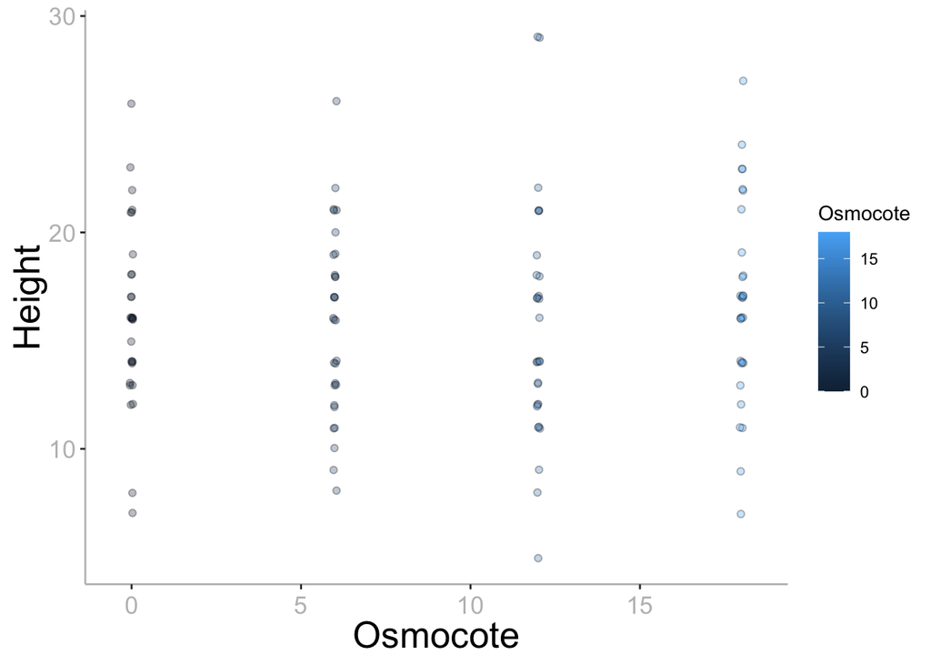

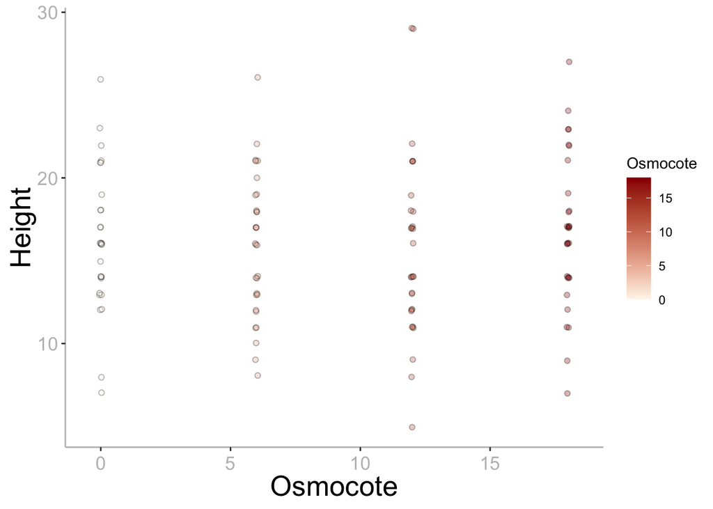

We want to give people the option to add a linear regression line:

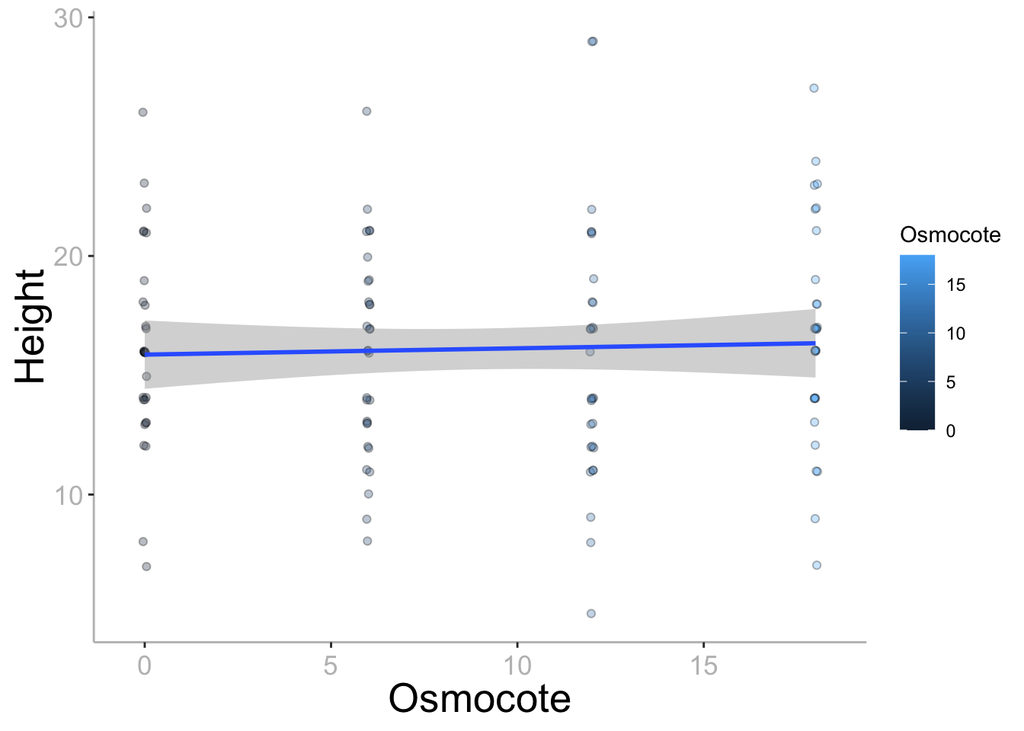

We can also do violin plots if one of the variables in categorical. We do not have any independent categorical variable right now (we only have osmocotes), but we could pretend that we have a categorical variable by treating the values of osmocotes as categories:

```r
dat2$osmocote.cat = factor(dat2$Osmocote)
str(dat2)
```

```
## 'data.frame':    117 obs. of  10 variables:
##  $ Osmocote    : int  0 0 0 0 0 0 0 0 0 0 ...
##  $ PlantID     : chr  "A1" "A2" "B1" "C1" ...
##  $ Height      : int  14 13 12 21 23 14 22 26 16 17 ...
##  $ CotWidth    : int  14 14 11 15 13 14 15 14 16 13 ...
##  $ Hairs       : chr  "etl" "16" "etl" "8" ...
##  $ Flowers     : num  5 3 6 6 3 4 8 4 6 5 ...
##  $ Bracts      : int  4 3 3 4 3 4 4 4 4 3 ...
##  $ Branches    : chr  "0" "0" "0" "0" ...
##  $ Pods        : int  3 2 3 4 2 2 4 3 4 3 ...
##  $ osmocote.cat: Factor w/ 4 levels "0","6","12","18": 1 1 1 1 1 1 1 1 1 1 ...
```

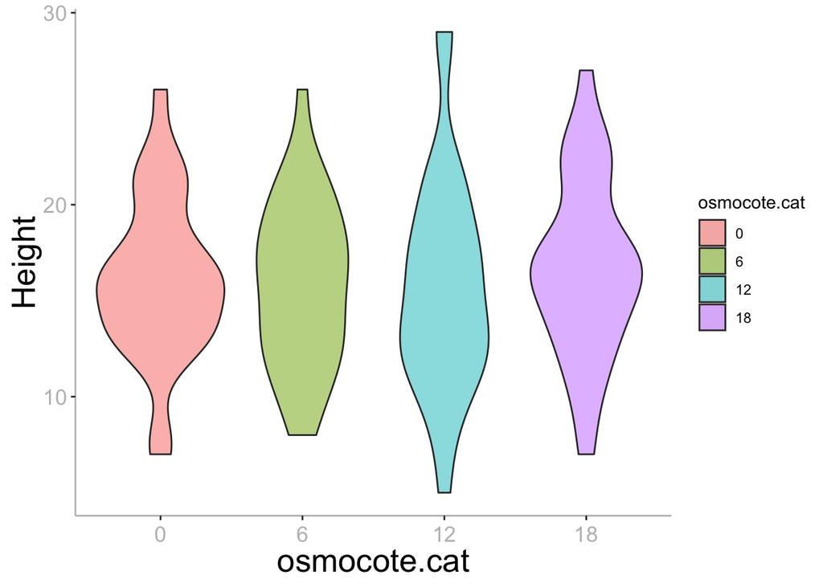

```r
p4 = ggplot(dat2, aes(x=osmocote.cat, y=Height, fill=osmocote.cat))+geom_violin(alpha=0.5)+
  theme(
        plot.title = element_text(hjust=0.5, size=rel(1.8)),
        axis.title.x = element_text(size=rel(1.8)),
        axis.title.y = element_text(size=rel(1.8), angle=90, vjust=0.5, hjust=0.5),
        axis.text.x = element_text(colour="grey", size=rel(1.5), angle=0, hjust=.5, vjust=.5, face="plain"),
        axis.text.y = element_text(colour="grey", size=rel(1.5), angle=0, hjust=.5, vjust=.5, face="plain"),
        panel.background = element_blank(),
        axis.line = element_line(colour = "grey")##,
        )

p4
```